# Exploratory Data Analysis: Factors Influencing IMDb Movie Quality

Author

Group 10

Published

March 19, 2026

# 1 Introduction

The following analysis explores the internal characteristics of the movie dataset to identify potential predictors for our Generalized Linear Model (GLM). We specifically focus on whether a movie achieves an IMDb rating greater than 7.

# 2 Exploratory Analysis

## 2.1 Data Summary & Descriptive Statistics

To understand the central tendency and dispersion of our movie features, we generated a summary table for numerical variables. As presented in Table 1, the dataset covers a wide range of years and budgets.

Table 1: Descriptive Statistics for Numerical Movie Features

| Variable | Mean | SD | Min | Max |
| --- | --- | --- | --- | --- |
| year | 1976.72 | 23.80 | 1903.0 | 2005.0 |
| length | 82.29 | 35.67 | 2.0 | 288.0 |
| budget | 12.00 | 2.89 | 3.2 | 22.1 |
| votes | 788.62 | 4501.33 | 5.0 | 84488.0 |
| rating | 5.36 | 2.09 | 0.8 | 8.9 |

The diversity of movie genres is another key aspect of our dataset. Table 2 shows the count and percentage of movies within each genre category after cleaning the missing values.

Table 2: Frequency and Percentage Distribution of Movie Genres

| genre | Count | Percentage |
| --- | --- | --- |
| Drama | 424 | 29.5% |
| Action | 412 | 28.7% |
| Comedy | 343 | 23.9% |
| Documentary | 95 | 6.6% |
| Animation | 85 | 5.9% |
| Short | 64 | 4.5% |
| Romance | 13 | 0.9% |

By reviewing Table 1, the variance of `votes` is exceptionally high compared to other predictors. This extreme dispersion indicates a “long-tail” distribution where a few extremely popular films receive a disproportionate amount of audience engagement, illustrating the need for a further transformation to stabilize the variable for the GLM. Furthermore, Table 2 highlights that Drama and Action are the most two prevalent categories in our sample. In contrast, Romance represents the smallest segment of the sample. This distribution reflects the producer’s focus on mainstream genres but suggests that the model’s predictive power for specific genres like Romance may be more limited.

## 2.2 Class Distribution

We examine the balance of our target variable (movie quality). As shown in Figure 1, we can observe the frequency of movies categorized as “Good” versus “Poor”.

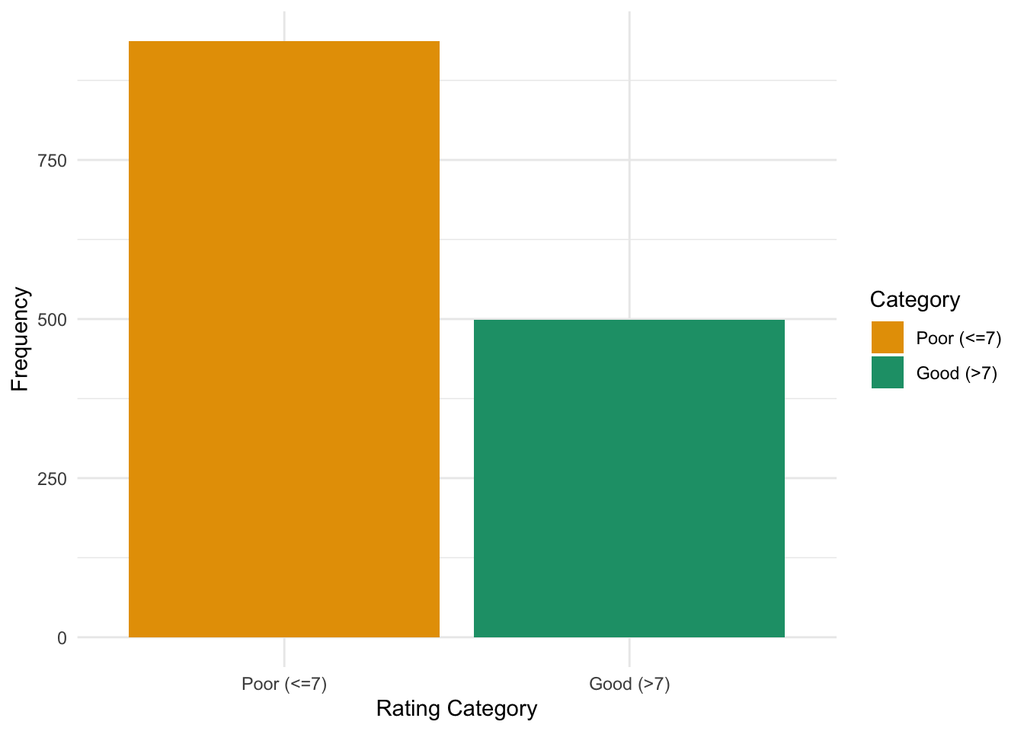

Figure 1: Distribution of Movie Quality Classes based on IMDb Ratings

Based on Figure 1, a significant class imbalance is observed in the target variable, with ‘Poor’ films ($Rating < 7$) outnumbering ‘Good’ films ($Rating > 7$) by nearly a factor of two. Because the model sees more examples of ‘Poor’ films, it might become better at identifying failures than predicting successes.

## 2.3 Numerical Variables vs Target

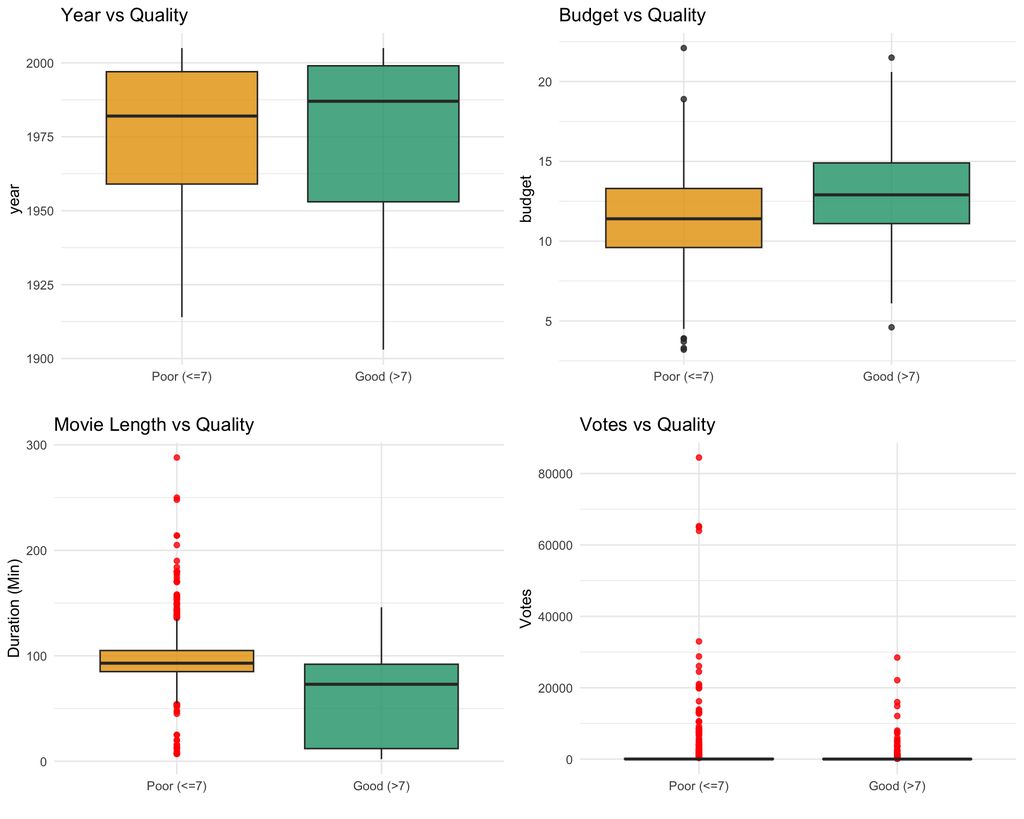

Figure 2: Boxplots of Movie Length, Budget, and Votes by Quality Category

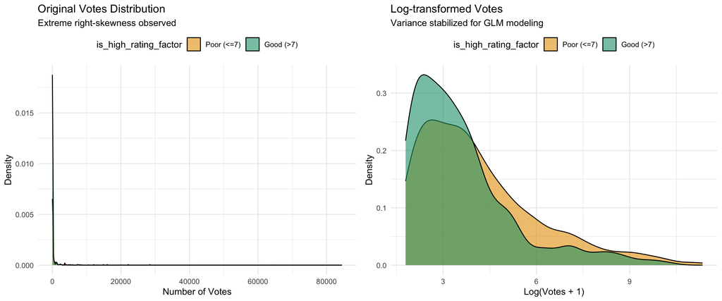

Figure 3: Comparison of Votes Distribution: Raw vs. Log-transformed